# A1 Analysis in R

Team 9

2024-03-09

#### Setting up the environment

Notes: setting up R environment by loading the libraries and installing packages.

## Introduction

The online ticket-selling strategies employed by Air France have proven to be effective in augmenting the number of visits to their website, with Media Contacts playing a pivotal role in achieving this outcome. As competition intensifies and prices escalate, the duty is on Media Contacts to leverage their expertise in marketing data analysis to optimize the returns on Air France’s investments. A thorough data-driven analysis, complemented by visualizations, was conducted to discern the strengths and weaknesses of the campaign results, thereby enabling the Marketing and Financial teams to make informed decisions on the utilization of the insights and recommendations provided.

Numerical outputs and visualizations were developed, adhering to the principle that “Without this visual analytics solution, one would be stuck analyzing enormous amounts of data in spreadsheets. Instead, the dashboards provide clear actionable insights that drive the business forward.” (Lay)The focus was predominantly on the financial ramifications of the strategies. To this end, outputs were generated, such as the Return on Investment (ROI), which facilitated the understanding and visualization of the profitability of each investment by comparing the gain or loss to its cost and assessing the return on investments. (Beattie, 2024)Additionally, an output that depicted the Conversion Rate between clicks and bookings was devised, accompanied by a respective Bar Chart, to enhance comprehension of each search engine’s performance.

Search Engine Marketing (SEM) inherently involves bidding on keywords pertinent to the advertised business, thereby rendering keyword research a vital component for targeting the desired audience. (Ooi, 2023) By identifying keywords relevant to their business, companies can craft effective ads that will appear when users search for those keywords. Consequently, a focus was placed on word performance, analyzing the different match types of word categories that resulted in bookings.

```r
# Install and load necessary packages
install.packages("tidytext",repos = 'http://cran.us.r-project.org' )
install.packages("stringr",repos = 'http://cran.us.r-project.org' )
install.packages("syuzhet",repos = 'http://cran.us.r-project.org')
install.packages("textdata",repos = 'http://cran.us.r-project.org' )
install.packages("DT", repos = 'http://cran.us.r-project.org')
library(dplyr)
```

```r
library(ggplot2)
library(wordcloud2)
library(tidyverse)
library(tm)
library(tidytext)
library(stringr)
library(syuzhet)
library(textdata)
library(DT)
# Setting up the current working directory
getwd()
```

```
## [1] "C:/Users/Initha/OneDrive/Documents/Business Challenge II"
```

```r
setwd("C:\\Users\\Initha\\OneDrive\\Documents\\Business Challenge II")
getwd()
```

```
## [1] "C:/Users/Initha/OneDrive/Documents/Business Challenge II"
```

```r
# Reading the CSV file
data <- read.csv("case_data.csv")

# Display first few rows
head(data, 4)
```

```
##   entry_id    Publisher.Name                        Keyword Match.Type
## 1  mkt_001   Google - Global                    fly to nice      Broad
## 2  mkt_002        Yahoo - US                 munich airport   Advanced
## 3  mkt_003 Overture - Global               chicago to paris   Advanced
## 4  mkt_005        Yahoo - US discount international airfare   Advanced
##                      Campaign                      Keyword.Group      Category
## 1  Air France Global Campaign                               Nice          nice
## 2 Western Europe Destinations                             Munich uncategorized
## 3                  Unassigned                         Unassigned         paris
## 4    Geo Targeted Los Angeles Discount International Los Angeles uncategorized
##          Bid.Strategy      Status Search.Engine.Bid Clicks Click.Charges
## 1       Position 1- 3 Unavailable             $1.25     15        $14.31
## 2                          Paused             $6.25      1         $5.71
## 3 Position 1-2 Target        Sent             $0.45     14         $5.99
## 4                          Paused             $6.25      9        $22.04
##   Avg..Cost.per.Click Impressions Engine.Click.Thru.. Avg..Pos. Trans..Conv...
## 1               $0.95         380               3.95%      1.85          0.00%
## 2               $5.71          25               4.00%      1.84          0.00%
## 3               $0.43       2,315               0.60%      4.48          0.00%
## 4               $2.45          86              10.47%      1.42          0.00%
##   Total.Cost..Trans. Amount Total.Cost Total.Volume.of.Bookings
## 1              $0.00  $0.00     $14.31                        0
## 2              $0.00  $0.00      $5.71                        0
## 3              $0.00  $0.00      $5.99                        0
## 4              $0.00  $0.00     $22.04                        0
```

```r
# Display the structure of the data
str(data, 4)
```

```
## 'data.frame':    4410 obs. of  21 variables:
##  $ entry_id                : chr  "mkt_001" "mkt_002" "mkt_003" "mkt_005" ...
##  $ Publisher.Name          : chr  "Google - Global" "Yahoo - US" "Overture - Global" "Yahoo - US" ...
##  $ Keyword                 : chr  "fly to nice" "munich airport" "chicago to paris" "discount international airfare" ...
##  $ Match.Type              : chr  "Broad" "Advanced" "Advanced" "Advanced" ...
##  $ Campaign                : chr  "Air France Global Campaign" "Western Europe Destinations" "Unassigned" "Geo Targeted Los Angeles" ...
##  $ Keyword.Group           : chr  "Nice" "Munich" "Unassigned" "Discount International Los Angeles" ...
##  $ Category                : chr  "nice" "uncategorized" "paris" "uncategorized" ...
##  $ Bid.Strategy            : chr  "Position 1- 3" "" "Position 1-2 Target" "" ...
##  $ Status                  : chr  "Unavailable" "Paused" "Sent" "Paused" ...
##  $ Search.Engine.Bid       : chr  "$1.25" "$6.25" "$0.45" "$6.25" ...
##  $ Clicks                  : chr  "15" "1" "14" "9" ...
##  $ Click.Charges           : chr  "$14.31" "$5.71" "$5.99" "$22.04" ...
##  $ Avg..Cost.per.Click     : chr  "$0.95" "$5.71" "$0.43" "$2.45" ...
##  $ Impressions             : chr  "380" "25" "2,315" "86" ...
##  $ Engine.Click.Thru..     : chr  "3.95%" "4.00%" "0.60%" "10.47%" ...
##  $ Avg..Pos.               : num  1.85 1.84 4.48 1.42 1.53 1.44 1 1.75 0.96 1 ...
##  $ Trans..Conv...          : chr  "0.00%" "0.00%" "0.00%" "0.00%" ...
##  $ Total.Cost..Trans.      : chr  "$0.00" "$0.00" "$0.00" "$0.00" ...
##  $ Amount                  : chr  "$0.00" "$0.00" "$0.00" "$0.00" ...
##  $ Total.Cost              : chr  "$14.31" "$5.71" "$5.99" "$22.04" ...
##  $ Total.Volume.of.Bookings: int  0 0 0 0 0 224 0 0 0 0 ...
```

```r
# Removing dollar sign from the variables
data$Search.Engine.Bid<-gsub("\\$","",data$Search.Engine.Bid)
data$Click.Charges<-gsub("\\$", "",data$Click.Charges)
data$Avg..Cost.per.Click<-gsub("\\$","",data$Avg..Cost.per.Click)
data$Total.Cost..Trans.<-gsub("\\$","",data$Total.Cost..Trans.)
data$Amount <-gsub("\\$","",data$Amount)
data$Total.Cost <-gsub("\\$","",data$Total.Cost)

# Removing percentage sign from the variables
data$Engine.Click.Thru..<-gsub("\\%","",data$Engine.Click.Thru..)
data$Trans..Conv...<-gsub("\\%","",data$Trans..Conv...)

# Removing commas from the variables
data$Clicks<-gsub(",", "",data$Clicks)
data$Click.Charges<-gsub(",", "",data$Click.Charges)
data$Impressions <-gsub(",","",data$Impressions)
data$Total.Cost..Trans.<-gsub(",","",data$Total.Cost..Trans.)
data$Amount <-gsub(",","",data$Amount)
data$Total.Cost <-gsub(",","",data$Total.Cost)

# Checking for the missing values if any in the data
sum(is.na(data))
```

```
## [1] 0
```

```r
# Checking for the incomplete cases in the data
data[!complete.cases(data),]
```

```
##  [1] entry_id                 Publisher.Name           Keyword
##  [4] Match.Type               Campaign                 Keyword.Group
##  [7] Category                 Bid.Strategy             Status
## [10] Search.Engine.Bid        Clicks                   Click.Charges
## [13] Avg..Cost.per.Click      Impressions              Engine.Click.Thru..
## [16] Avg..Pos.                Trans..Conv...           Total.Cost..Trans.
## [19] Amount                   Total.Cost               Total.Volume.of.Bookings
## <0 rows> (or 0-length row.names)
```

```r
#changing datatype from character to numeric
data$Search.Engine.Bid <- as.numeric(data$Search.Engine.Bid)
data$Clicks<-as.numeric(data$Clicks)
data$Click.Charges <-as.numeric(data$Click.Charges)
data$Avg..Cost.per.Click<-as.numeric(data$Avg..Cost.per.Click)
data$Impressions <-as.numeric(data$Impressions)
data$Engine.Click.Thru.. <-as.numeric(data$Engine.Click.Thru..)
data$Trans..Conv... <-as.numeric(data$Trans..Conv...)
data$Total.Cost..Trans. <-as.numeric(data$Total.Cost..Trans.)
data$Amount <-as.numeric(data$Amount)
data$Total.Cost <-as.numeric(data$Total.Cost)
data$Total.Volume.of.Bookings <-as.numeric(data$Total.Volume.of.Bookings)

str(data, 4)
```

```
## 'data.frame':    4410 obs. of  21 variables:
##  $ entry_id                : chr  "mkt_001" "mkt_002" "mkt_003" "mkt_005" ...
##  $ Publisher.Name          : chr  "Google - Global" "Yahoo - US" "Overture - Global" "Yahoo - US" ...
##  $ Keyword                 : chr  "fly to nice" "munich airport" "chicago to paris" "discount international airfare" ...
##  $ Match.Type              : chr  "Broad" "Advanced" "Advanced" "Advanced" ...
##  $ Campaign                : chr  "Air France Global Campaign" "Western Europe Destinations" "Unassigned" "Geo Targeted Los Angeles" ...
##  $ Keyword.Group           : chr  "Nice" "Munich" "Unassigned" "Discount International Los Angeles" ...
##  $ Category                : chr  "nice" "uncategorized" "paris" "uncategorized" ...
##  $ Bid.Strategy            : chr  "Position 1- 3" "" "Position 1-2 Target" "" ...
##  $ Status                  : chr  "Unavailable" "Paused" "Sent" "Paused" ...
##  $ Search.Engine.Bid       : num  1.25 6.25 0.45 6.25 7.5 27.5 6.25 0.13 8.75 6.25 ...
##  $ Clicks                  : num  15 1 14 9 1 ...
##  $ Click.Charges           : num  14.31 5.71 5.99 22.04 4.63 ...
##  $ Avg..Cost.per.Click     : num  0.95 5.71 0.43 2.45 4.63 1.59 1.5 0.56 0.27 1.89 ...
##  $ Impressions             : num  380 25 2315 86 19 ...
##  $ Engine.Click.Thru..     : num  3.95 4 0.6 10.47 5.26 ...
##  $ Avg..Pos.               : num  1.85 1.84 4.48 1.42 1.53 1.44 1 1.75 0.96 1 ...
##  $ Trans..Conv...          : num  0 0 0 0 0 0.77 0 0 0 0 ...
##  $ Total.Cost..Trans.      : num  0 0 0 0 0 ...
##  $ Amount                  : num  0 0 0 0 0 ...
##  $ Total.Cost              : num  14.31 5.71 5.99 22.04 4.63 ...
##  $ Total.Volume.of.Bookings: num  0 0 0 0 0 224 0 0 0 0 ...
```

```r
# Checking null values
sum(is.na(data))
```

```
## [1] 0
```

```r
# Output 1

# replace the blanks values in Bid Strategy as "NO BID"
data[data$Bid.Strategy== "", "Bid.Strategy"] <- "NO BID"
data[data$Bid.Strategy== "", "Bid.Strategy"]
```

```
## character(0)
```

```r
head(data$Bid.Strategy, 4)
```

```
## [1] "Position 1- 3"       "NO BID"              "Position 1-2 Target"
## [4] "NO BID"
```

#### Output 1

Making sure that ‘Bid.Strategy’ column in the data has no blank values. Replacing blanks with “NO BID” provides a clear, definitive label for entries without a specified bidding strategy. This line enhances data integrity and makes it easy to interpret ‘Bid.Strategy’ column.This brings consistency which is crucial for filtering and analysis. Identifying and labeling entries as “NO BID” could reveal how often and under what circumstances bid strategies are not specified. This insight could lead to strategic adjustments, such as identifying opportunities for optimization.

```r
# Output 2

# replace the NA values in match type as "NOT SPECIFIED"
data[data$Match.Type == "N/A", "Match.Type"] <- "Not Specified"
data[data$Match.Type== "N/A", "Match.Type"]
```

```
## character(0)
```

```r
head(data$Match.Type, 4)
```

```
## [1] "Broad"    "Advanced" "Advanced" "Advanced"
```

#### Output 2

The code looks through the Match Type column to search for all rows with N/A. A new variable called “Not Specified” is also created. The new variable is set to replace all N/A in Match Type. This is to preprocess the data by replacing missing or placeholder values (“N/A”) with a more descriptive label (“Not Specified”). This to ensure the data do not have ambiguous values, which could affect data analysis.

```r
# Output 3

# Summary statistics of numeric fields
data_statistics <- summary(select(data, where(is.numeric)))
print(head(data_statistics, 5))
```

```
##  Search.Engine.Bid     Clicks        Click.Charges      Avg..Cost.per.Click
##  Min.   : 0.000    Min.   :    1.0   Min.   :    0.05   Min.   : 0.040
##  1st Qu.: 3.750    1st Qu.:    1.0   1st Qu.:    2.28   1st Qu.: 0.830
##  Median : 6.250    Median :    4.0   Median :    6.62   Median : 1.660
##  Mean   : 5.444    Mean   :  103.6   Mean   :  158.39   Mean   : 1.894
##  3rd Qu.: 6.250    3rd Qu.:   18.0   3rd Qu.:   27.18   3rd Qu.: 2.660
##   Impressions      Engine.Click.Thru..   Avg..Pos.      Trans..Conv...
##  Min.   :      1   Min.   :  0.010     Min.   : 0.000   Min.   :  0.00
##  1st Qu.:     27   1st Qu.:  1.530     1st Qu.: 1.140   1st Qu.:  0.00
##  Median :    171   Median :  4.095     Median : 1.590   Median :  0.00
##  Mean   :   8929   Mean   : 11.197     Mean   : 1.931   Mean   :  0.53
##  3rd Qu.:    829   3rd Qu.: 10.920     3rd Qu.: 2.310   3rd Qu.:  0.00
##  Total.Cost..Trans.     Amount           Total.Cost
##  Min.   :   0.00    Min.   :     0.0   Min.   :    0.05
##  1st Qu.:   0.00    1st Qu.:     0.0   1st Qu.:    2.28
##  Median :   0.00    Median :     0.0   Median :    6.62
##  Mean   :  24.64    Mean   :   912.1   Mean   :  158.39
##  3rd Qu.:   0.00    3rd Qu.:     0.0   3rd Qu.:   27.18
##  Total.Volume.of.Bookings
##  Min.   :  0.0000
##  1st Qu.:  0.0000
##  Median :  0.0000
##  Mean   :  0.7698
##  3rd Qu.:  0.0000
```

#### Output 3

This is a quick statistical summary of all numeric fields in the data. It includes measures of central tendency (mean, median) and dispersion for each numerical column. Such statistics are crucial for understanding the distribution and scale of our data, helping us identify any outliers or anomalies that may affect the analysis. All these numeric columns will determine the cost and revenue analytically process of the analysis.

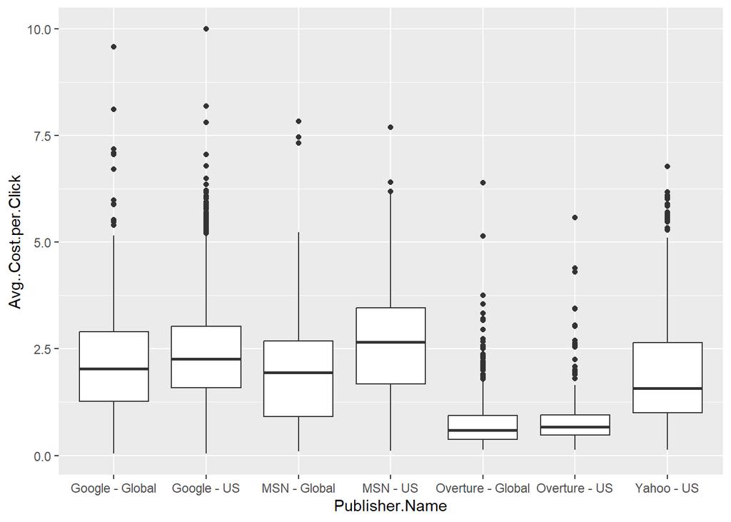

```r
# Visualization 1

#Creating box plots for Publisher and their Average cost for each clicks
publisher_avg_cost <- ggplot(data = data, aes(x = Publisher.Name,
                                              y = Avg..Cost.per.Click))
publisher_avg_cost + geom_boxplot()
```

#### Visualization 1

This data helps businesses in decide where to place their advertisements in order to achieve the highest return on investment.

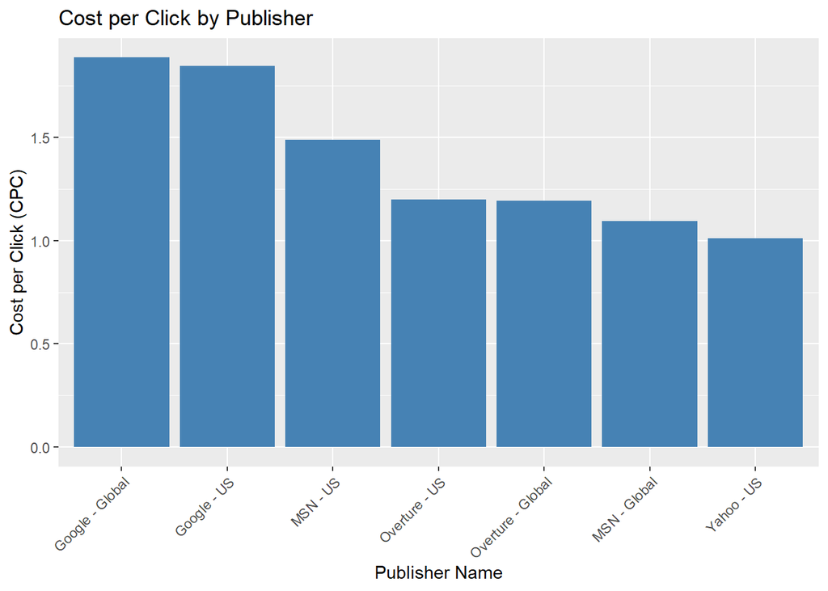

```r
# Visualization 2

# Calculating Cost per Click per Publisher Name
publisher_cpc <- data %>%
  group_by(Publisher.Name) %>%
  summarize(Total_Cost = sum(Total.Cost), Total_Clicks = sum(Clicks),
            CPC = ifelse(Total_Clicks > 0, Total_Cost / Total_Clicks, 0)) %>%
  arrange(desc(CPC))

# Creating the bar chart for Cost per Click
ggplot(publisher_cpc, aes(x = reorder(Publisher.Name, -CPC), y = CPC)) +
  geom_bar(stat = "identity", fill = "steelblue") +
  theme(axis.text.x = element_text(angle = 45, hjust = 1)) +
  labs(x = "Publisher Name", y = "Cost per Click (CPC)",
       title = "Cost per Click by Publisher")
```

#### Visualization 2

The chart clearly shows CPC pricing differences amongst publishers that may influences marketers. Advertisers may select Yahoo US for the most cost-effective clicks. Google’s services, while more expensive, may have a wider reach or perceived value. This data can help advertisers in budgeting campaigns and selecting cost-effective platforms.

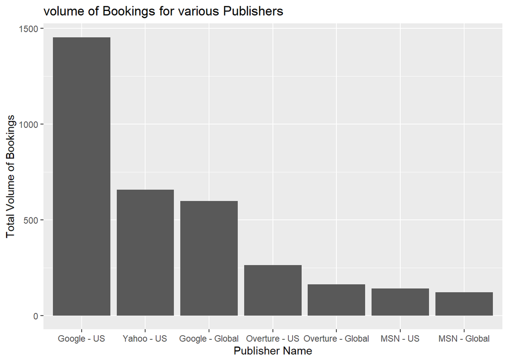

```r
# Visualization 3

# Aggregate and Sum Bookings by Publisher
agg_book <- aggregate(Total.Volume.of.Bookings~Publisher.Name, data = data, FUN = sum)
agg_book <- agg_book[order(-agg_book$Total.Volume.of.Bookings), ]

# Creating bar chart for publisher and the booking
ggplot(data = agg_book, aes(x = reorder(Publisher.Name, -Total.Volume.of.Bookings),
                            y = Total.Volume.of.Bookings)) +
  geom_bar(stat = "identity") +
  labs(x = "Publisher Name", y = "Total Volume of Bookings",
       title = "volume of Bookings for various Publishers")
```

#### Visualization 3

In the bars for “US” market publishers are often higher than their “Global” competitors, which could indicate that these publishers perform better or have a stronger presence in the US market.

```r
# Output 4

# Count of Publishers
Publishers <- length(unique(data$Publisher.Name))
print(paste("Publishers:", Publishers))
```

```
## [1] "Publishers: 7"
```

#### Output 4

The analysis is about individual Publishers in the data. This will aid in determining the effectiveness and reach of the Publishers’ skills, as well as their consumer involvement. Unique function is attached to the Publisher Name so that Publishers’ name that appears more than once, will not be counted more than one. Length function is attached to the unique Publishers’ name so that it counts the total instead of listing. The insights are going to be based on Publisher’s result so knowing their total is a way to go.

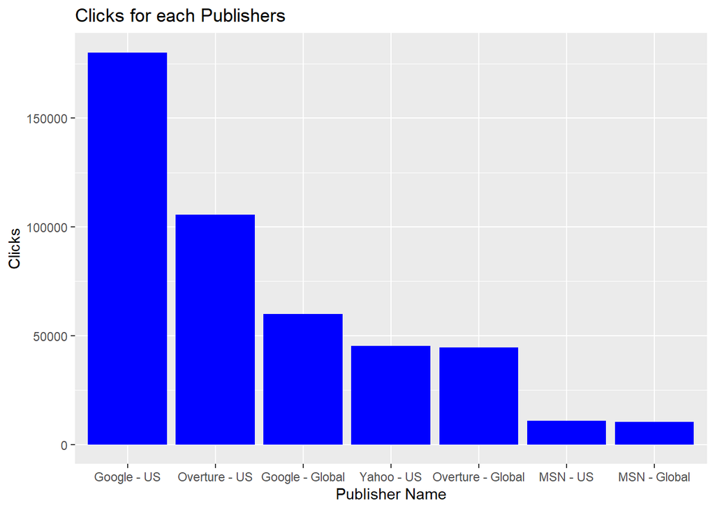

```r
# Visualization 4

# Aggregate and Sum Clicks by Publisher:
agg_clicks <- aggregate(Clicks~Publisher.Name, data = data, FUN = sum)
agg_clicks <- agg_clicks[order(-agg_clicks$Clicks), ]

#Bar chart for publisher and the clicks
ggplot(data = agg_clicks, aes(x = reorder(Publisher.Name, -Clicks),
                                    y = Clicks)) +
  geom_bar(stat = "identity", fill = "blue") +
  labs(x = "Publisher Name", y = "Clicks",
       title = "Clicks for each Publishers")
```

#### Visualization 4

This could reveal numerous aspects, including Google’s dominance in the US market and the global success of these publishers. It also demonstrates the huge contrast in click volumes between marketplaces and publications.

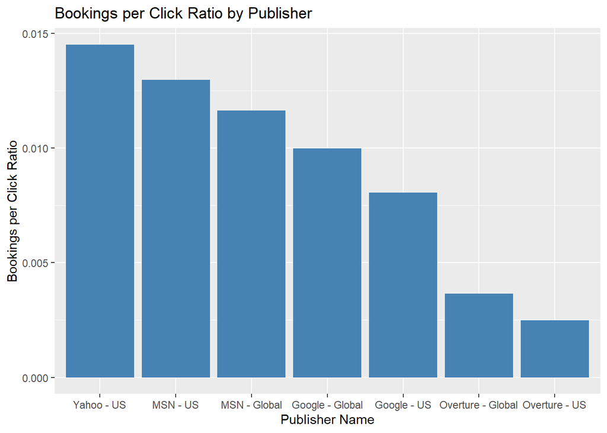

```r
# Visualization 5

# Calculating the ratio of Total Volume of Bookings to Clicks for each publisher
publisher_cr <- data%>%
  group_by(Publisher.Name) %>%
  summarize(Total_Bookings = sum(Total.Volume.of.Bookings), Total_Clicks = sum(Clicks),
            Booking_Click_Ratio = ifelse(Total_Clicks > 0, Total_Bookings / Total_Clicks, 0)) %>%
  arrange(desc(Booking_Click_Ratio))

# Creating the bar chart
ggplot(publisher_cr, aes(x = reorder(Publisher.Name, -Booking_Click_Ratio),
                         y = Booking_Click_Ratio)) +
  geom_bar(stat = "identity", fill = "steelblue") +
  labs(x = "Publisher Name", y = "Bookings per Click Ratio",
       title = "Bookings per Click Ratio by Publisher")
```

#### Visualization 5

The bar chart named “Bookings per Click Ratio by Publisher” that compares the efficiency of bookings to clicks across various publishers in both the US and global markets. It highlights:

1. Yahoo - US has the best bookings per click ratio, indicating that it converts the most clicks into bookings when compared to its click count.
2. MSN - US comes next, with a slightly lower ratio than Yahoo - US but still greater than the rest, demonstrating good market efficiency in the United States.
3. MSN - Global, Google - Global, and Google - US have successively lower ratios, showing that while they receive a lot of clicks, the conversion to bookings is not as great as Yahoo - US or MSN - US.
4. Overture - Global and Overture - US have the lowest bookings per click ratios, implying that they may require more clicks to obtain a booking than others.

This measure is frequently used to assess an ad publisher’s performance in turning clicks into bookings, with greater ratios being considered better. According to the bars, some publishers may be more effective globally, while others may flourish in the United States.

```r
# Output 5

# Total clicks converted to Booking for each Publisher
conversion_rates <- data %>%
  group_by(Publisher.Name) %>%
  summarise(Total_Clicks = sum(Clicks, na.rm = TRUE),
            Total_Bookings = sum(Total.Volume.of.Bookings, na.rm = TRUE),
            Conversion_Rate = (Total_Bookings / Total_Clicks) * 100) %>%
  arrange(desc(Conversion_Rate))

# Display the conversion rates
print(conversion_rates)
```

```
## # A tibble: 7 × 4
##   Publisher.Name    Total_Clicks Total_Bookings Conversion_Rate
##   <chr>                    <dbl>          <dbl>           <dbl>
## 1 Yahoo - US               45198            656           1.45
## 2 MSN - US                 10788            140           1.30
## 3 MSN - Global             10494            122           1.16
## 4 Google - Global          59918            598           0.998
## 5 Google - US             180208           1453           0.806
## 6 Overture - Global        44661            163           0.365
## 7 Overture - US           105541            263           0.249
```

#### Output 5

This code is created to give an overview of the rate at which each Publishers, clicks turns to booking. This shows how each cost the client pays for each click for every publisher turns to revenue to the client. Total bookings were divided by total clicks to show the rate clicks are converted. This shows how effective publishers have been able to push adverts to the right customers. This have been arranged in descending order for proper analysis. The results showed that Yahoo - US gave a higher conversion rate of 1.45%. Meaning that 1.45% of every click we pay for turns into booking which is the primary aim for business.

```r
# Output 6

# Calculate Net Returns (Amount - Total Cost) by Publisher
net_returns_publisher <- data %>%
  group_by(Publisher.Name) %>%
  summarise(
    # Calculate net returns for each publisher
    Net_Returns = sum(as.numeric(Amount)) - sum(as.numeric(Total.Cost))
  ) %>%
  # Arranging in descending order of net returns for fast analysis
  arrange(desc(Net_Returns))

# Display Results
print(net_returns_publisher)
```

```
## # A tibble: 7 × 2
##   Publisher.Name    Net_Returns
##   <chr>                   <dbl>
## 1 Google - US          1316772.
## 2 Yahoo - US            832648.
## 3 Google - Global       559705.
## 4 Overture - US         191429.
## 5 MSN - US              165488.
## 6 Overture - Global     129902.
## 7 MSN - Global          128099.
```

#### Output 6

This code is created to give an overview of the total returns received from the investment in advertising with each Publisher. This shows the revenue generated from each Publisher. This has been calculated as the Amount received less the cost for each Publisher. This will be a metric in the analysis to determine whether the investment is been optimized. This have been arranged in descending order for proper analysis. From the results, it is seen that Google - US is giving a Net Returns of $1,316,772 followed by Yahoo _ US with $832,648. the next output will be to show if these results are based on conversion rates or just because there were a lot of adverts placed that brought out that returns. Further analysis will be conducted for investment optimization.

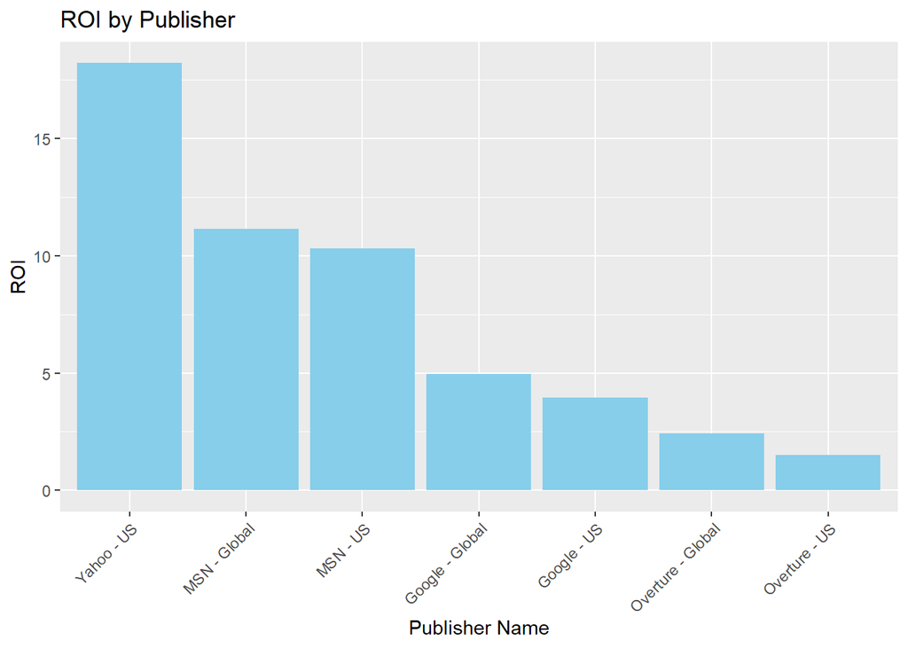

```r
# Visualization 6

# Calculating ROI per Publisher Name
publisher_roi <- data %>%
  group_by(Publisher.Name) %>%
  summarize(Total_Amount = sum(Amount), Total_Cost = sum(Total.Cost),
            ROI = ifelse(Total_Cost > 0, (Total_Amount - Total_Cost) / Total_Cost, 0)) %>%
  arrange(desc(ROI))

# Creating the bar chart for ROI
ggplot(publisher_roi, aes(x = reorder(Publisher.Name, -ROI), y = ROI)) +
  geom_bar(stat = "identity", fill = "skyblue") +
  theme(axis.text.x = element_text(angle = 45, hjust = 1)) +
  labs(x = "Publisher Name", y = "ROI", title = "ROI by Publisher")
```

#### Visualization 6

The bar chart labelled “ROI by Publisher” that calculates the Return on Investment (ROI) for various publishers. It highlights:

1. Yahoo - US has the greatest ROI, with a number greater than 15, suggesting that investing in Yahoo’s US advertisements yields much larger returns than other publishers.
2. MSN - Global and MSN - US come next, with MSN - Global marginally outperforming MSN - US, indicating a good ROI for these areas.
3. Google - Global has a ROI of about 5, which is moderate compared to the others, whereas Google - US is slightly lower, indicating a poorer return per investment in these regions.
4. Overture - Global has a ROI that is around half that of Google, indicating inferior investment efficiency.
5. Overture - US has the lowest ROI on the chart, implying that investing in Overture’s US ads yields the lowest return compared to the others.

The chart indicates which publishes and markets may generate higher financial returns on advertising spend. Advertisers must take such data into account when developing marketing strategy.

```r
# Output 7

# Display calculated value
publisher_roi
```

```
## # A tibble: 7 × 4
##   Publisher.Name    Total_Amount Total_Cost   ROI
##   <chr>                    <dbl>      <dbl> <dbl>
## 1 Yahoo - US             878340.     45692. 18.2
## 2 MSN - Global           139597.     11498. 11.1
## 3 MSN - US               181550.     16062. 10.3
## 4 Google - Global        672712.    113007.  4.95
## 5 Google - US           1649182.    332410.  3.96
## 6 Overture - Global      183220.     53318.  2.44
## 7 Overture - US          317942.    126513.  1.51
```

#### Output 7

```r
# Visualization 7

# Checking summary and the structure of the match type
summary(data$Match.Type)
```

```
##    Length     Class      Mode
##      4410 character character
```

```r
str(data$Match.Type)
```

```
##  chr [1:4410] "Broad" "Advanced" "Advanced" "Advanced" "Not Specified" ...
```

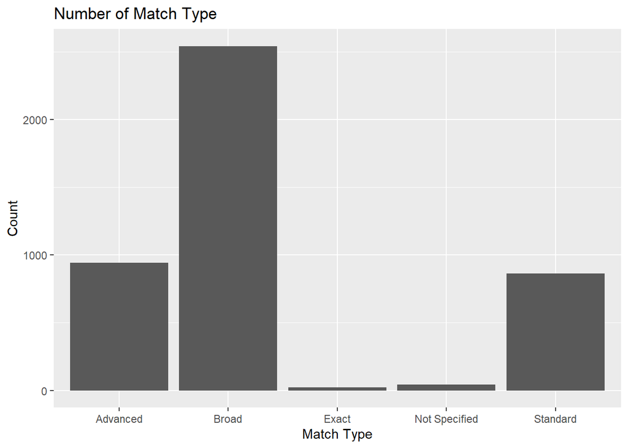

```r
# Plotting histogram of match type for the keywords
# Creating a bar chart
mat_typ <- ggplot(data= data, aes(x= Match.Type))
mat_typ + geom_bar() +
  labs(x = "Match Type", y = "Count", title = "Number of Match Type")
```

#### Visualization 7

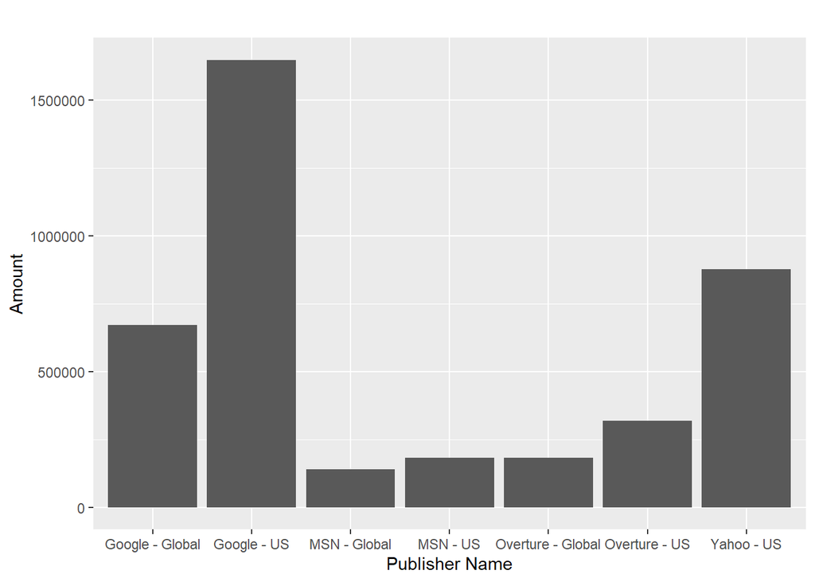

```r
# Visualization 8

# Creating a bar chart
rev<- ggplot(data= data, aes(x= Publisher.Name, y= Amount)) +
  geom_bar(stat="identity") +
  labs(x = "Publisher Name", y = "Amount", title = "")
rev
```

#### Visualization 8

The distribution demonstrates Google’s dominance, notably in the United States, and implies that Yahoo, while not at Google’s level, holds a solid position in comparison to MSN and Overture. The close numbers for MSN global and US presence may reflect consistent success across markets.

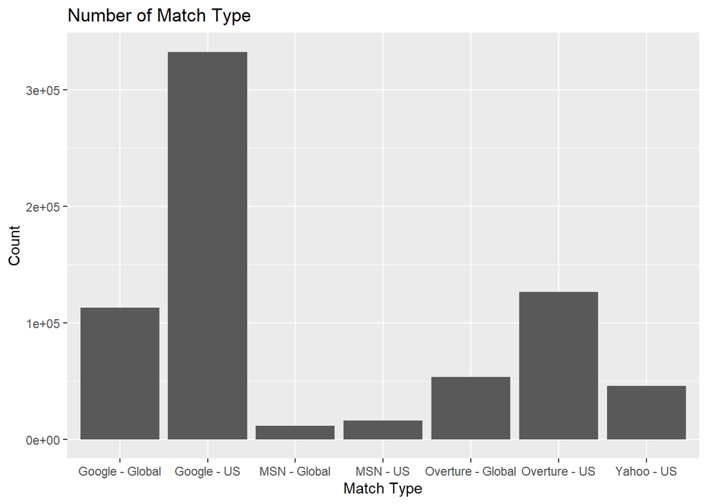

```r
# Visualization 9

# Creating a bar chart
amt_spnd <- ggplot(data= data, aes(x= Publisher.Name, y= Total.Cost)) +
  geom_bar(stat="identity") +
  labs(x = "Match Type", y = "Count", title = "Number of Match Type")
amt_spnd
```

#### Visualization 9

```r
# Visualization 10

## word cloud
names(data)[names(data) == 'Keyword'] <- 'text'

wld_cld <- VCorpus(VectorSource(data$text))
wld_cld <- tm_map(wld_cld, content_transformer(tolower))  # convert to lower case
wld_cld <- tm_map(wld_cld, removePunctuation)             # remove punctuation
wld_cld <- tm_map(wld_cld, removeNumbers)                 # remove numbers
wld_cld <- tm_map(wld_cld, stripWhitespace)               # remove redundant spaces

tidy_text <- tidy(wld_cld)
tidy_text <- data %>%
  mutate(row = row_number()) %>%
  unnest_tokens(word, text)

print(colnames(tidy_text))
```

```
##  [1] "entry_id"                 "Publisher.Name"
##  [3] "Match.Type"               "Campaign"
##  [5] "Keyword.Group"            "Category"
##  [7] "Bid.Strategy"             "Status"
##  [9] "Search.Engine.Bid"        "Clicks"
## [11] "Click.Charges"            "Avg..Cost.per.Click"
## [13] "Impressions"              "Engine.Click.Thru.."
## [15] "Avg..Pos."                "Trans..Conv..."
## [17] "Total.Cost..Trans."       "Amount"
## [19] "Total.Cost"               "Total.Volume.of.Bookings"
## [21] "row"                      "word"
```

```r
print(colnames(stop_words))
```

```
## [1] "word"    "lexicon"
```

```r
tidy_text <- tidy_text %>%
  anti_join(stop_words, by = "word")

word_freq <- tidy_text %>%
  count(word, sort = TRUE)
print(head(word_freq, 4))
```

```
##     word   n
## 1  cheap 772
## 2 flight 767
## 3  paris 724
## 4 france 717
```

```r
wordcloud2(word_freq,
           color='random-light',
           shape = 'cloud',
           rotateRatio = 1)
```

[interactive chart not shown]

#### Visualization 10

The word cloud, which is a visual representation of text data in which the size of each word represents its frequency or relevance. Travel-related terms, notably flights and air travel, dominate this word cloud. Important findings from the word cloud:

1. The word “flight” and “cheap” are the most common, implying a heavy emphasis on low-cost air travel.
2. The titles of various European cities and countries, such as “France,” “Paris,” “Rome,” “Italy,” and “Europe,” reflect a concentration on this region.
3. Words like “Tickets,” “Fares,” “Airfare,” and “Discount” are also used frequently, highlighting the cost of air travel.
4. The appearance of the word “Airline” alongside specific cities shows that the data is related to searches or discussions regarding airlines that serve these areas.
5. The term “airport” and the names of specific cities denote a possible study of air travel routes or destinations.

Overall, the word cloud appears to indicate subjects connected to searching for or discussing economical flight.

```r
# Output 8

# Defining a data frame named kayak_tab
kayak_tab <- data.frame(
  Search_Engine = "Kayak",
  Clicks = 2839,
  Media_Cost = 3567.13,
  Total_Bookings = 208,
  Avg_Ticket = 1123.53,
  Total_Revenue = 233694.00,
  Net_Revenue = 230126.87,
  stringsAsFactors = FALSE
)

# Display an interactive table with DT
datatable(kayak_tab, options = list(pageLength = 5, scrollX = TRUE))
```

|  | Search_Engine | Clicks | Media_Cost | Total_Bookings | Avg_Ticket | Total_Revenue | Net_Revenue |
| --- | --- | --- | --- | --- | --- | --- | --- |
| 1 | Kayak | 2839 | 3567.13 | 208 | 1123.53 | 233694 | 230126.87 |

```r
# Display kayak data as a tabular output
print(kayak_tab)
```

```
##   Search_Engine Clicks Media_Cost Total_Bookings Avg_Ticket Total_Revenue
## 1         Kayak   2839    3567.13            208    1123.53        233694
##   Net_Revenue
## 1    230126.9
```

#### Output 8

Clicks (2839), this metric indicating a reasonable degree of user participation. Media Cost ($3567.13), the total campaign budget. Total Bookings (208), number of successful transactions resulting from clicks. Average Ticket ($1123.53), high revenue suggests a premium offering or numerous items per transaction. Total Revenue ($233694.00) is the campaign’s gross income. Net Revenue ($230126.87) profit after deducting ad cost, indicating a very successful campaign. Revenue on ads, exceptionally high, with each dollar invested yielding about $65.49. Conversion Rate at 7.32%, it demonstrates strong performance in converting clicks into bookings. CPA at $17.15 per booking, the campaign is reasonably priced. Overall, the data suggests a profitable ad campaign, but this does not account for other operating expenditures.

```r
# Output 9

# Calculate Cost Per Click for each publisher
Cost_per_Click_Publisher <- data %>%
  group_by(Publisher.Name) %>%
  summarise(
    Total_Cost = sum(as.numeric(Total.Cost), na.rm = TRUE),
    # Sum up clicks, also ignoring NA values
    Total_Clicks = sum(Clicks, na.rm = TRUE),
    # Calculate CPC; avoid division by zero by setting CPC to NA when no clicks are present
    Cost_Per_Click = ifelse(Total_Clicks > 0, Total_Cost / Total_Clicks, NA)
  ) %>%
  arrange(desc(Cost_Per_Click))

# Display the calculated Cost-Per_Click for each publisher
print(Cost_per_Click_Publisher)
```

```
## # A tibble: 7 × 4
##   Publisher.Name    Total_Cost Total_Clicks Cost_Per_Click
##   <chr>                  <dbl>        <dbl>          <dbl>
## 1 Google - Global      113007.        59918           1.89
## 2 Google - US          332410.       180208           1.84
## 3 MSN - US              16062.        10788           1.49
## 4 Overture - US        126513.       105541           1.20
## 5 Overture - Global     53318.        44661           1.19
## 6 MSN - Global          11498.        10494           1.10
## 7 Yahoo - US            45692.        45198           1.01
```

#### Output 9

This operation is aimed at evaluating the cost efficiency of clicks across different publishers. After knowing the Net Returns and Return on Investment by Publishers, knowing cost per click for each publisher will help the analyse how to place advertisement with the publishers that will give the desired bookings whiles controlling or reducing the cost associated thereof. This has calculated by dividing the total cost by the total clicks by each publisher to determine cost per click. The lower the cost per click, the better. However, that will be conclusive if the lower clicks are leading to higher bookings and higher returns on investment. Yahoo - US have the lowest cost per click of $1.01, followed by MSN - Global with $1.10 and Google – Global Google - US having $1.89 and $1.84 respectively.

```r
# Output 10

# Calculating metrics by Match Type
Match_type_metrics <- data %>%
  group_by(Match.Type) %>%
  summarise(
    Total_Clicks = sum(Clicks, na.rm = TRUE),
    Total_Impressions = sum(Impressions, na.rm = TRUE),
    Total_Bookings = sum(Total.Volume.of.Bookings, na.rm = TRUE),
    Conversion_Rate = (Total_Bookings / Total_Clicks) * 100
  ) %>%
  mutate(Conversion_Rate = ifelse(is.nan(Conversion_Rate), 0, Conversion_Rate)) # Replace NaN with 0 in case of division by zero

# Display the calculated metrics
print(Match_type_metrics)
```

```
## # A tibble: 5 × 5
##   Match.Type    Total_Clicks Total_Impressions Total_Bookings Conversion_Rate
##   <chr>                <dbl>             <dbl>          <dbl>           <dbl>
## 1 Advanced             88514          14809846            758          0.856
## 2 Broad               215044           4717206           1640          0.763
## 3 Exact                45294            236914            672          1.48
## 4 Not Specified         1070            592612              1          0.0935
## 5 Standard            106886          19021090            324          0.303
```

#### Output 10

In Search Engine Marketing and Optimization, keywords play active role and must be selected carefully. For this reason, the analysis focuses on keyword analysis in the match type category. The goal of keyword match type analysis is to establish which match types used in advertisements result in the most bookings, while keeping in mind that the goal is to generate bookings rather than clicks. This can help you understand how different match types affect overall campaign performance, identifying areas where you may improve conversion rates and effectiveness through optimization. The results revealed that exact match types had the greatest conversion rate of 1.48. As a result, it is recommended that you employ exact match keywords.

## Conclusion

In conclusion, Yahoo has been identified as the most cost-effective search engine in terms of cost per click and return on investment, positioning it as the optimal choice for AirFrance. It is advisable for AirFrance to reallocate a portion of its budget from Google to Yahoo, thereby enhancing revenue optimization without increasing the overall investment. To ensure the effectiveness of this strategy, it is recommended that the results be monitored on a monthly basis to maintain a record of the strategy’s performance.

## Bibliography

Beattie, A. (2024, 2 28). ROI: Return on Investment Meaning and Calculation Investopedia. Retrieved from https://www.investopedia.com/articles/basics/10/guide-to-calculating-roi.asp

Lay, D. (n.d.). A Guide To Data Driven Decision Making: What It Is, Its Importance, & How To Implement It. Retrieved from tableau: https://www.tableau.com/learn/articles/data-driven-decision-making

Ooi, J. (2023, 08 18). The Importance of Keyword Research in SEM: Maximizing Your Online Visibility. Retrieved from nightowl: https://nightowl.sg/blog/the-importance-of-keyword-research-in-sem-maximizing-your-online-visibility/